# GroDataDmorv — Analyse de l’équilibrage de Pokémon

Équipe Grodatadmorv

24 juin 2026

# Introduction

## Pokémon

Pokémon Rouge et Vert sont des jeux de rôle japonais (J-RPG) sortis initialement en 1996 au Japon. L’objectif du jeu est de capturer, élever et faire s’affronter des créatures, les Pokémon, dans des combats au tour par tour. Pour plus d’informations à ce sujet, se référer à [cette page Wikipédia](https://fr.wikipedia.org/wiki/Syst%C3%A8me_de_jeu_de_Pok%C3%A9mon) ou à [la page Poképédia dédiée](https://www.pokepedia.fr/Combat_Pok%C3%A9mon) au système de combat.

## Pourquoi faire de la visu sur Pokémon ?

Premièrement, parce que nous aimons ces jeux. Cette raison se suffirait presque à elle-même si Pokémon n’était pas aussi riche dans ses systèmes de jeu et dans son volet compétitif qu’il ne l’est et qu’il ne l’est devenu. Nous n’aborderons pas ou très peu dans cette analyse les produits dérivés du jeu (cartes, animés, peluches, mangas, transport aérien ([oui oui](https://www.ana.co.jp/fr/fr/the-ana-experience/pikachujet/))…), qui constituent en réalité le cœur de la stratégie pour la licence la plus lucrative de l’Histoire. Les jeux et leurs mécaniques seuls constituent déjà un sujet extrêmement vaste que nous tâcherons toutefois de couvrir dans toute sa diversité.

# Données

Nous proposons d’étudier l’équilibrage de Pokémon sous deux angles complémentaires :

- **angle RPG** : ce que le jeu propose (stats, attaques, types, talents, répartition des créatures dans l’espace de jeu, etc.)
- **angle compétitif** : ce qu’en font les joueurs en stratégie Pokémon (usages, combinaisons, movesets, etc.)

L’idée est de croiser ces deux niveaux pour mieux comprendre si les Pokémon performants en compétitif le sont parce que leurs caractéristiques de base sont plus favorables, ou parce que le contexte du métagame amplifie certains profils.

## Sources

Nos deux sources sont les [statistiques de Smogon](https://smogon.com/stats/), développeurs du simulateur de jeu open-source [*Pokémon Showdown*](https://play.pokemonshowdown.com), et [PokeAPI](https://github.com/pokeapi/pokeapi), une API open-source qui donne des données générales sur les Pokémon.

### Statistiques Smogon (usage/métagame)

Données mensuelles de décembre 2014 à aujourd’hui, couvrant 136 mois et 150 Pokémon en Gen 1 OU. Les données incluent :

- **Usage** : taux d’utilisation et nombre brut de sélections
- **Moves** : taux d’utilisation de chaque attaque par Pokémon
- **Teammates** : corrélations de sélection entre coéquipiers
- **Leads** : Pokémon envoyés en premier dans les combats
- **Checks/Counters** : scores d’efficacité défensive entre paires

### PokeAPI

Base de données statique couvrant 1025 espèces de Pokémon (toutes générations), incluant les statistiques de base, types, couleurs, formes, habitats, taux de capture, et chaînes d’évolution.

# Analyse des données

## Question 1 : Quels Pokémon sont les plus utilisés, et lesquels sont sous-représentés dans le métagame étudié ?

En utilisant le dataset Smogon (Gen 1 OU, agrégé sur l’ensemble des mois disponibles de décembre 2014 à aujourd’hui), nous pouvons identifier les Pokémon les plus et les moins joués dans le métagame compétitif de la première génération.

### Graphique n°1 : Top 15 des Pokémon les plus représentés

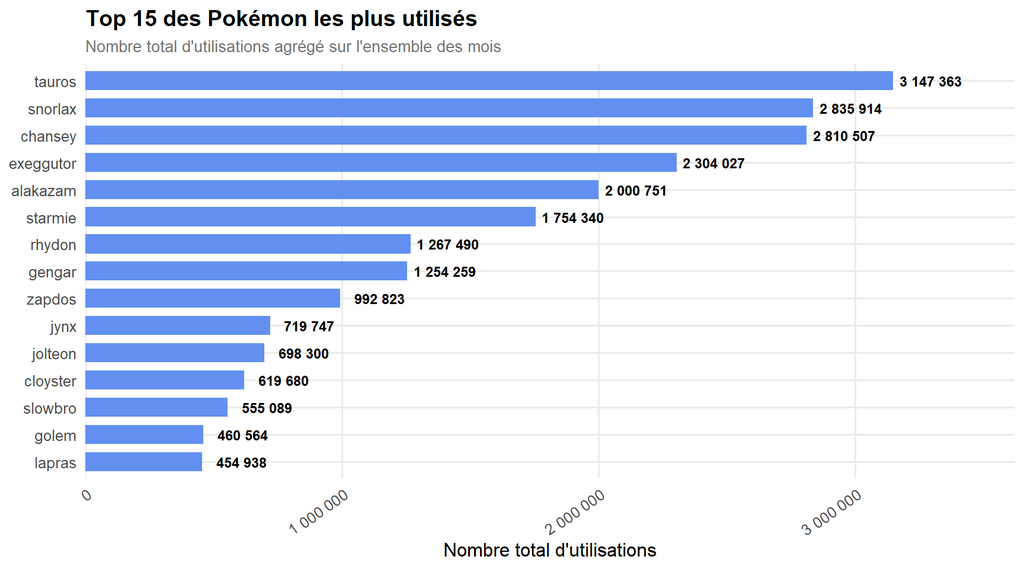

### Graphique n°2 : Top 15 des Pokémon les plus sous-représentés

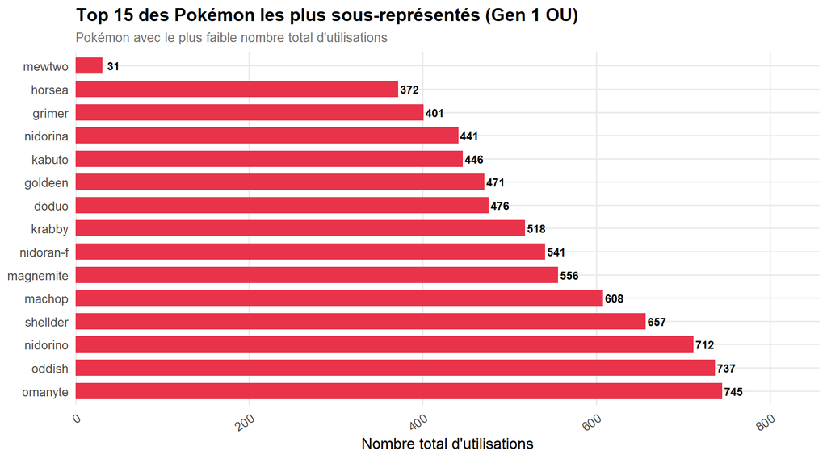

### Graphique n°3 : Distribution de l’utilisation des Pokémon

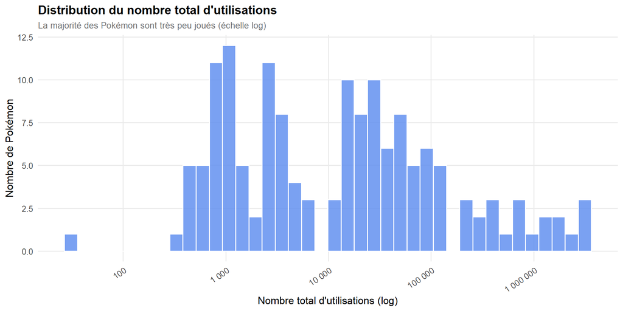

Sur ces deux graphiques, on voit clairement que l’immense majorité des Pokémon ne sont presque pas utilisés, et qu’une minorité (~10 Pokémon) est jouée presque tout le temps. La distribution est extrêmement asymétrique (right-skewed), ce qui est typique des métagames compétitifs : quelques Pokémon dominent, tandis que la plupart sont relégués à un usage anecdotique.

## Question 3 : Quel est la génération la plus représentée parmis les pokemon les plus joués de chaque génération ?

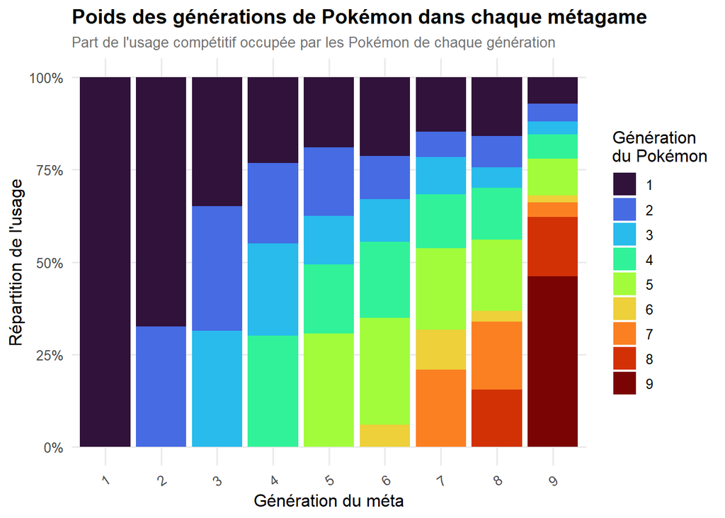

L’analyse des premières générations est assez simple. On note évidemment qu’à la première génération, 100% des usages étaient de cette même génération. les 2 suivantes ajoutant moins de Pokémons, les puissants des précédentes gardent une place importante. La 6e génération marque l’arrivée des Méga-évolutions, une forme plus puissante accordée à certains Pokémons, dont beaucoup sont de la 1ère génération. Enfin, la neuvième ajoute les Paradoxes, qui sont très puissants et prennent donc une grande part de l’usage (Par exemple, le plus utilisé de cette génération est Fort-Ivoire).

## Question 5 : Observe-t-on des combinaisons récurrentes (teammates) qui signalent des synergies fortes ?

En croisant chaque Pokémon avec ses coéquipiers les plus fréquents, on peut calculer un **indice d’association** : de combien de points de pourcentage l’usage d’un coéquipier est plus élevé dans les équipes contenant le Pokémon de référence, comparé à sa moyenne générale. Un indice fortement positif signale une synergie récurrente ; un indice négatif signale au contraire des Pokémon que l’on évite d’associer.

### Graphique n°1 : Top 15 des synergies les plus fortes

[figure not shown]

La synergie la plus marquée est Chansey et Tauros avec un indice de 12.942. Au total, 1011 paires dépassent un indice de 10, ce qui signale des associations nettement non aléatoires entre certains Pokémon du métagame.

[figure not shown]

## Question 6 : Quel type d’attaque sont les plus utilisés dans les différentes générations ? Est-ce corrélé avec leur type le plus présent ?

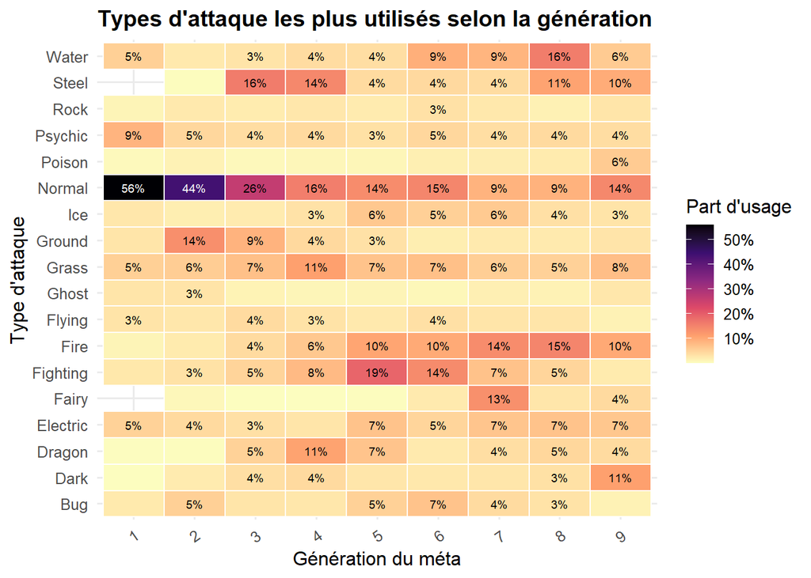

On souhaite maintenant savoir si ces choix d’attaques sont liés aux types des Pokémons utilisés. Cela serait logique à cause du concept de STAB (Same Type Attack Bonus), qui augmente les dégâts des attaques utilisées par un Pokémon de leur type.

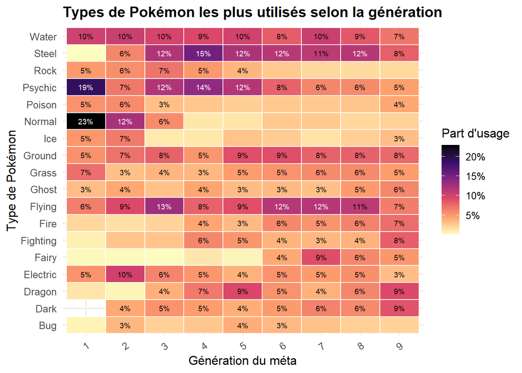

Il ne semble pas y avoir de corrélation pour tous les types (les Pokémons les plus utilisés n’ont pas forcément les types d’attaques les plus représentés). Cela s’explique à la fois par la présence de doubles types, dont l’un des deux peut être utilisé pour le STAB et l’autre non, mais aussi par le choix souvent fait de donner à son équipe des attaques de types différents, permettant d’offrir une meilleure couverture offensive.

Pour finir cette analyse, on peut tenter de déterminer quels types semblent être plus utilisés offensivement (plus d’attaques que de Pokémons) et lesquels seraient plutôt défensifs (plus de Pokémons que d’attaques). Cette analyse sera réalisée sur l’ensemble des générations pour avoir le plus de valeurs possibles.

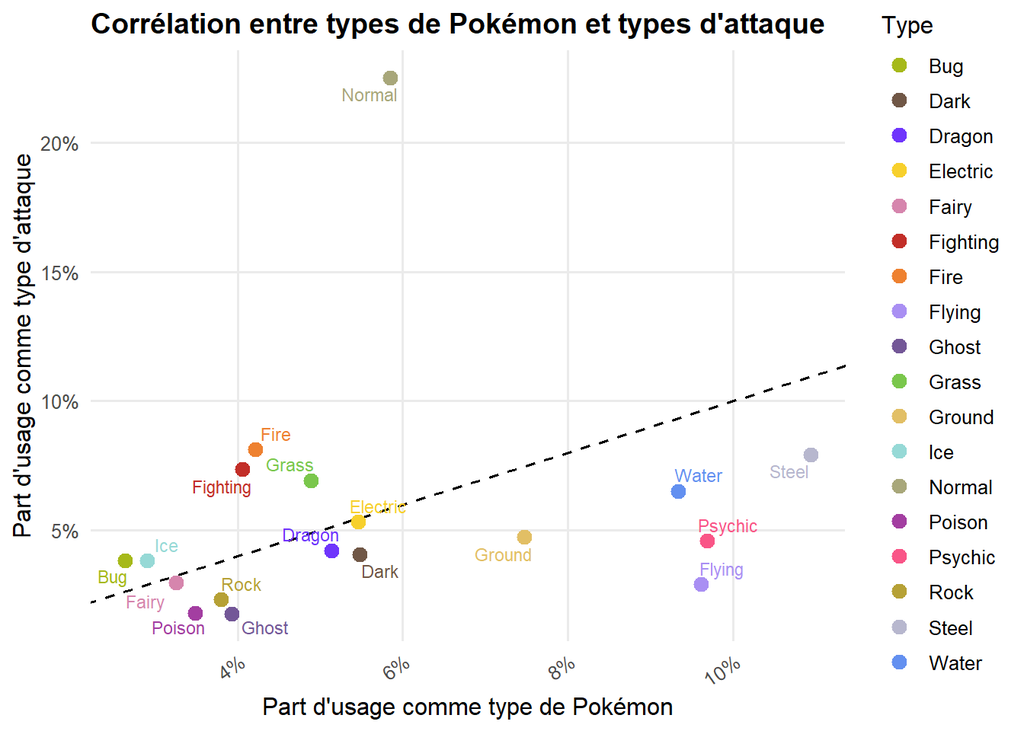

On remarque ainsi que certains types semblent bel et bien être utilisés de chaque manière. Cette analyse est intéressante, mais nous étudierons plus en détail les performances de chaque type plus tard. On peut toujours noter l’anomalie qu’est le type normal, qui s’explique de la même manière que pour la première visualisation.

## Équilibrage & Game Design

## Question 8 : La distribution des statistiques est-elle équlibrée au sein d’une même génération ? Et entre les générations ?

Puisque les Pokémon ont des profils assez différents (un Pokémon défensif aura des statistiques offensives réduites, un Pokémon Spécial aura des statistiques physiques plus faibles….), on peut s’attendre à ce que les statistiques soient en moyenne égales dans une même génération. De plus, les joueurs de Pokémon parlent du “power creep”, le fait que les Pokémons des générations plus récentes aient de meilleures statistiques que les plus anciens, ce que l’on devrait pouvoir l’observer

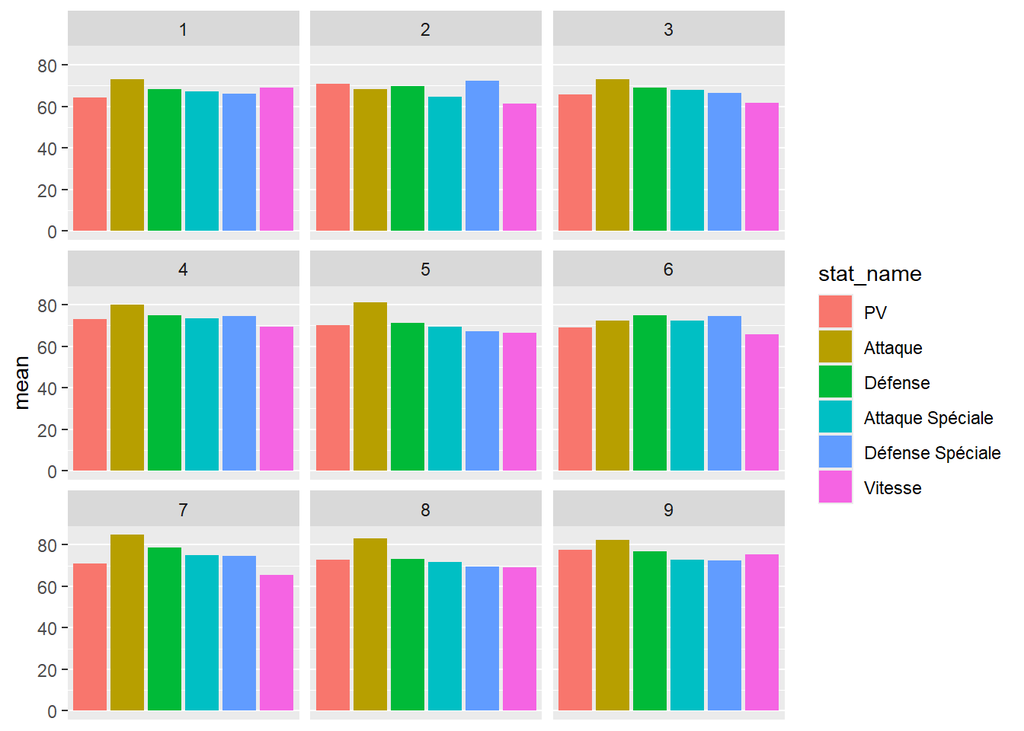

On remarque que dans la majorité des générations, l’Attaque est plus élevée que les autres statistiques, parfois de beaucoup. Dans la plupart, la défense est deuxième, bien que cela soit moins flagrant. On peut ainsi imaginer qu’il existe plus de Pokémon offensifs sur le physique que d’autres profils. En ce qui concerne le “power creep”, il est bel et bien visible: les valeurs augmentent au fil des générations.

### Certains Pokémon ont-ils un profil plus spécialisé (ex: haute attaque faible attaque spéciale), certains sont-ils plus homogènes ?

Pour cette analyse, on peut tenter de déterminer la moyenne de chaque statistique selon la statistique la plus élevée de chaque Pokémon.

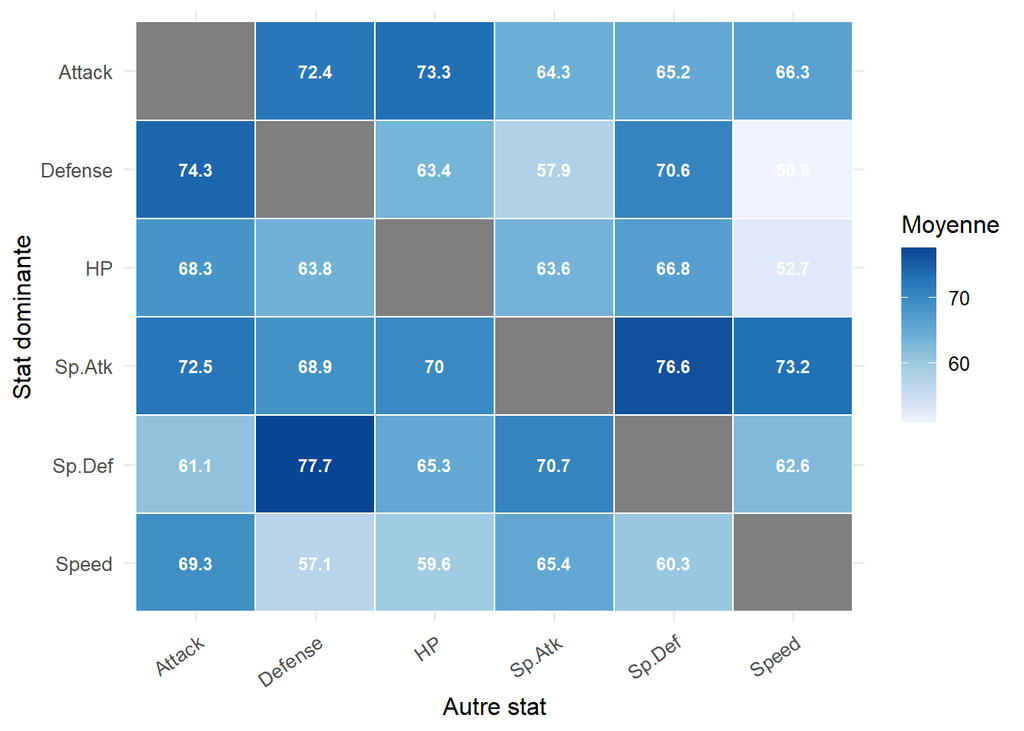

## Question 9 : Certains types sont-ils sur ou sous-représentés parmi les Pokémon dominants ?

Pour répondre à cette question, on compare la distribution des types dans le Pokédex de première génération à leur présence dans le métagame Gen 1 OU de Smogon. Les Pokémon à double type comptent une fois pour chacun de leurs types : Exeggutor contribue donc à la fois au type Grass et au type Psychic.

Les données PokeAPI décrivent les types actuels. On reconstruit donc localement les types de génération 1, afin d’éviter de compter des types introduits plus tard comme Steel ou Fairy.

### Graphique n°1 : Types présents dans le top 15

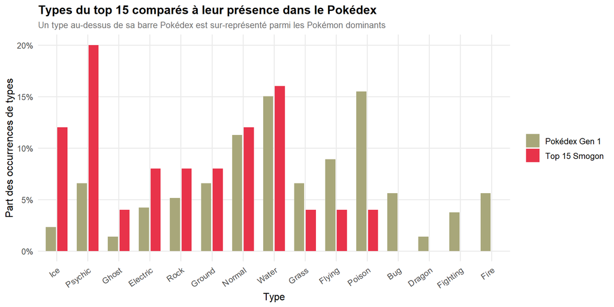

Dans le top 15, les types Ice, Psychic et Ghost ressortent très fortement : Ice représente environ 12 % des occurrences de types du top 15 contre seulement 2,3 % dans le Pokédex Gen 1, et Psychic monte à 20 % contre 6,6 %. À l’inverse, Bug, Fighting et Fire sont absents du top 15, alors qu’ils existent bien dans le bestiaire.

### Graphique n°2 : Ratio de représentation pondéré par l’usage

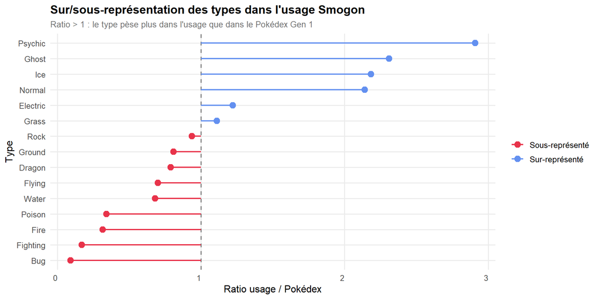

Le classement pondéré par l’usage nuance légèrement le top 15, mais confirme les mêmes familles de types. Psy est le type le plus avantagé : il pèse presque 3 fois plus dans l’usage Smogon que dans le Pokédex de génération 1. Spectre, Glace et Normal sont aussi très au-dessus de leur poids théorique. Normal est notamment porté par Tauros, Leveinard et Ronflex, trois piliers du métagame.

### Synthèse

Les meilleurs types du métagame étudié semblent être Psy, Glace, Spectre et Normal. Psy bénéficie d’une position centrale dans la première génération avec Alakazam, Lippoutou et Flagadoss.

Le type Glace quant à lui profite du collectif : avec quelques Pokémon très efficaces comme Lippoutou (Psy/Glace), Crustabri (Eau/Glace) et Lokhlass (Eau/Glace). C’est un type défensivement assez faible, mais c’est un bon coverage offensif avec des attaques puissantes pour complémenter un autre type éliminer la menace Dracolosse sur qui les dégats Glace sont multipliés par 4.

Normal n’est pas intrinsèquement rare, mais ses meilleurs représentants concentrent énormément d’usage.

Spectre n’est représenté que par la famille d’Ectoplasma, très populaire grâce à sa vitesse et son spécial, mais dont le type spectre (physique) est stérilisé par son attaque abyssale. L’immunité aux types Normal et Combat est cependant très appréciée car elle permet de placer Ectoplasma en switch-in contre des Pokémon très courants comme Tauros ou Ronflex.

Les pires types sont Insecte, Combat et Feu, suivis par Poison. Leur faible présence dans les Pokémon dominants indique que l’équilibrage de la première génération ne donne pas la même valeur compétitive à tous les types : le type seul ne suffit pas à expliquer l’usage, mais il structure clairement les chances d’apparition au sommet du métagame.

## Question 10 : Quels sont les doubles types les plus représentés dans le jeu ?

Il est très courant pour un Pokémon d’avoir un double type. Cependant, malgré les plus de 1000 Pokémon existants, certains doubles types n’ont toujours pas été utilisés (comme par exemple le double type Insecte-Dragon). Les développeurs ont-ils des favoris, avec des types disposant de plus d’associations que d’autres ?

### Graphique n°1 : Nombre de doubles types existants par type

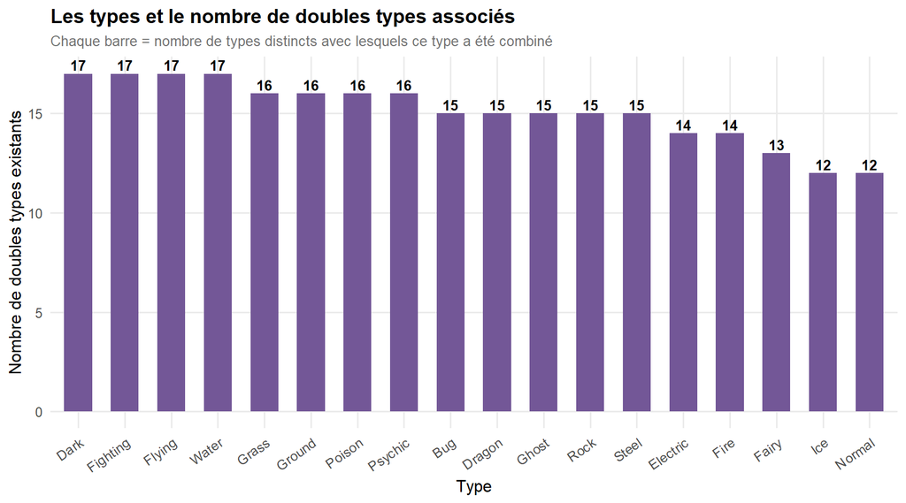

On voit que la plupart des types sont au-dessus de 15, donc proches du maximum de 17 associations possibles (18 types − soi-même). Cependant, certains types restent en retrait : le type Fée, introduit plus tardivement que les 17 autres, et le type Glace, qui semble boudé par Game Freak. Il est également étonnant de trouver le type Feu aussi bas, puisque c’est un type de Pokémon de départ très apprécié des joueurs.

### Graphique n°2 : Heatmap des doubles types et leur nombre de représentants

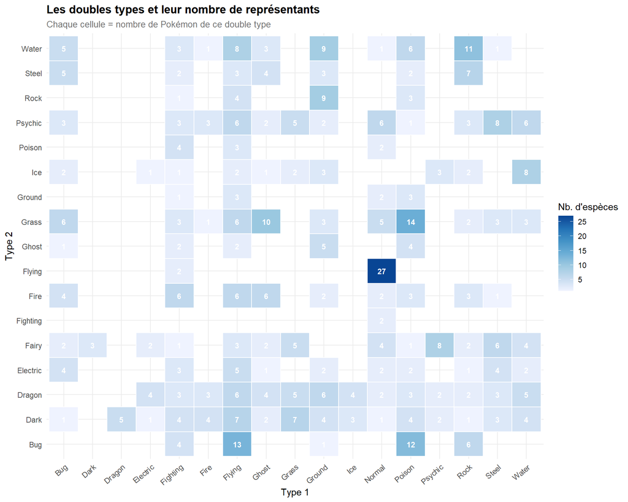

Sur cette visualisation, on voit que certains doubles types sont beaucoup plus représentés que d’autres. Le type Normal-Vol est de loin le plus présent, ce qui s’explique notamment par l’absence de Pokémon de type Vol pur, souvent remplacés par des types Normal-Vol. On remarque aussi des concentrations notables pour Eau-Sol, Herbe-Poison, ou encore Insecte-Vol.

## Question 11 : Certains types ont-ils un avantage offensif/défensif intrinsèque dans le tableau des faiblesses/résistances (couverture, immunités) ?

Tout les types ne sont pas crées égaux. Certains ne dispose que de peu de résistance par rapport à leur nombre de faiblesse, tandis que d’autre dispose de nombreuse résistance mais ne sont pas très fort offensivement. Quels types sont les plus avantagés sur le plan défensif et offensif ?

Pour la première moitié de cette question nous allons nous intéresser à l’état actuel des choses en 9eme génération, en incluant donc les changements fait en 2eme, 5eme et 6eme générations sur la table des types. Ensuite, nous ferons un état des choses tels quels étaient en 1ere génération.

### Graphique n°1: ratio de résistance et faiblesse de chaque type:

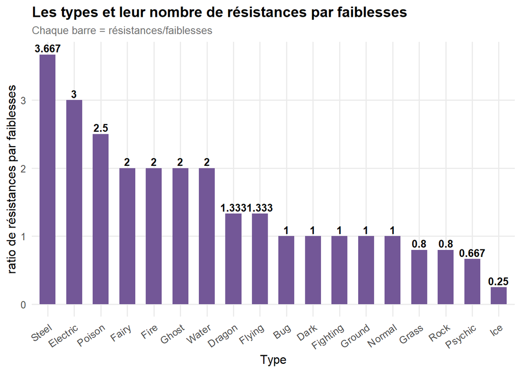

### Graphique n°2: efficacité de couverture offensive de chaque type (super efficace sur combien de type et résisté par combien de types):

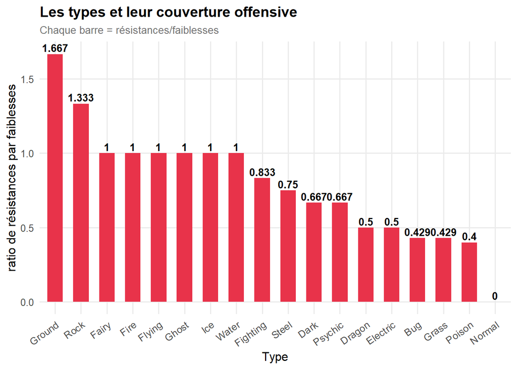

On voit bien, que les types ne sont pas tous crées de la même manière. Un type comme le type acier par exemple dispose d’énormément de résistance pour peu de faiblesse, mais dispose d’une capacité offensive limitée, alors que le type sol n’est pas excellent défensivement mais est super efficace sur beaucoup de type. Cependant, ces dataviz ne présente pas tout. Certains types comme le type spectre ne sont pas super efficace sur beaucoup de type mais ne sont pas résisté par beaucoup de type. Ces types restent donc très fort offensivement, car il est très dur d’y résister.

### Graphique n°3: ratio de résistance et faiblesse de chaque type en 1ère génération:

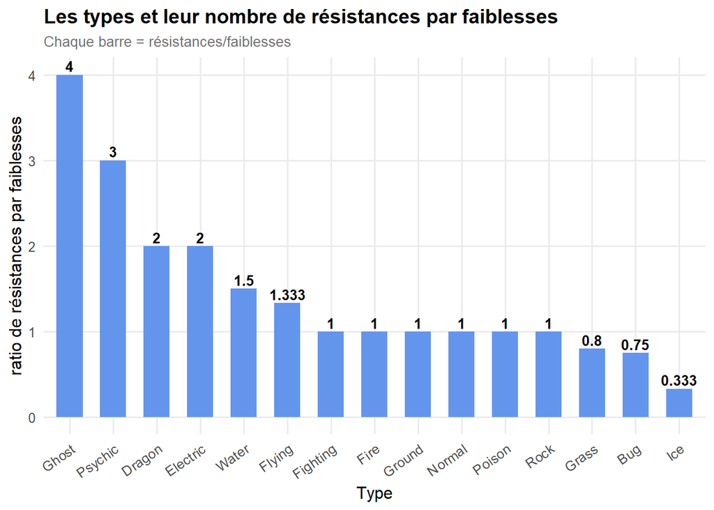

### Graphique n°4: efficacité de couverture offensive de chaque type (super efficace sur combien de type et résisté par combien de types):

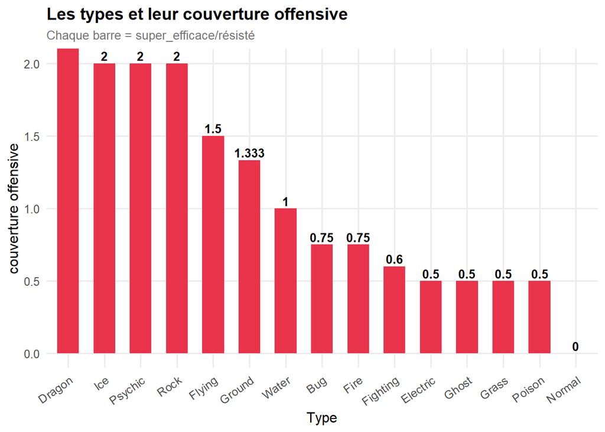

## Question 12 : Les nouvelles générations introduisent-elles beaucoup plus d’attaque et de talent uniques que les anciennes ? (`moves.csv`, `abilities.csv`)

Dans les nouvelles générations, il est courant que les pokemon introduits aient des talents ou des attaques uniques, pour les différencier des pokemon existant. On a donc tendance à penser que plus les générations avances, plus pokemon introduit de nouvelles attaques et de nouveaux talents. Dans cette question, nous allons essayer de vérifier cette intuition.

## Graphique n°1: nombre de talents introduits au cours des générations.

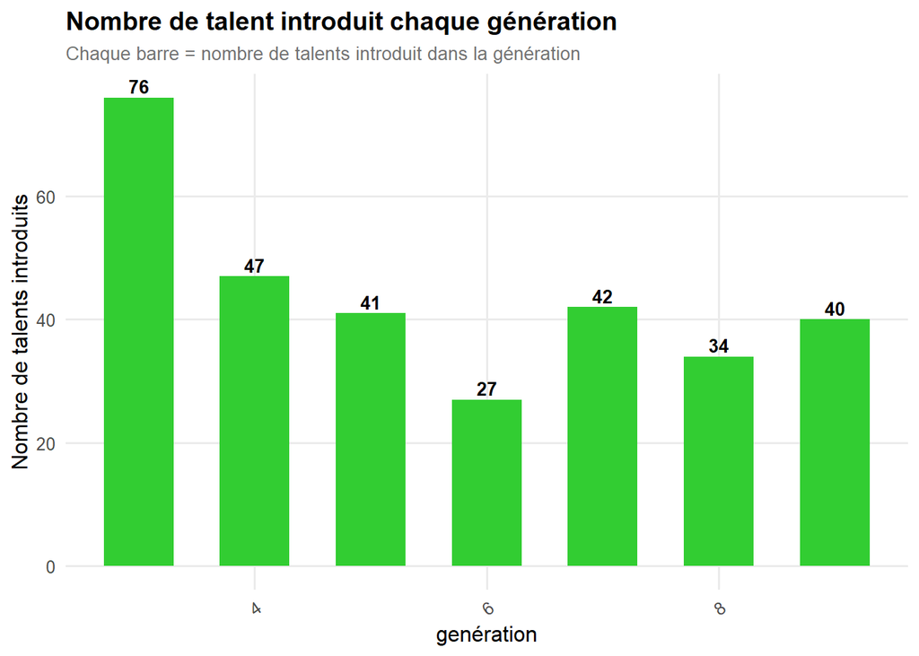

Dans ce graphique, on peut voir que la 3eme génération est la génération introduisant le plus de type et de loin. C’est assez normal, puisque c’est la génération qui introduit le principe de talent. A part la 3eme génération, il est difficile d’identifier une tendance, puisque la plupart des génération introduisent une quarantaine de talent. La seule exception est la 6ème génération, qui n’ajoute que très peu de nouveaux talents. Cette disparité peu peut-être s’expliquer par l’introduction des méga-évolutions, qui réutilise souvent des anciens talents ou se partage des talents entre-elles (par exemple le talent peau céleste a été crée pour les méga-évolutions, mais est donné à plusieurs méga-évolutions.)

## Graphique n°2: nombre d’attaques introduites au cours des générations.

[figure not shown]

Dans ce second graph on peut noter que la première générations est celle qui a introduit le plus d’attaque, ce qui semble logique car c’est le premier jeu de la série. On ne peu pas remarquer de tendance précise, car la plupart des génération tourne autour des 100 attaques introduites. La 6eme génération n’introduit que peu d’attaque, ce qui peu peut-être s’expliquer par l’introduction des méga-évolutions, qui garde les mêmes attaques que le pokemon qui méga-évolue. La 7ème génération introduit beaucoup d’attaque, à cause des attaques Z, qui est la méchanique de génération. Enfin, surprenamment, la 9ème génération n’introduit que très peu de nouvelles attaques, ce qui va à l’inverse de notre intuition originale. Cependant, ici on ne regarde pas la distribution de ces attaques. On pourrait vouloir savoir si les attaques introduites sont distribuées à beaucoup de pokemon, ou uniquement aux nouveaux pokemon, ce qui avantagerait les nouveaux pokemon.

## Graphique n°3: nombre de talents signature de chaque générations.

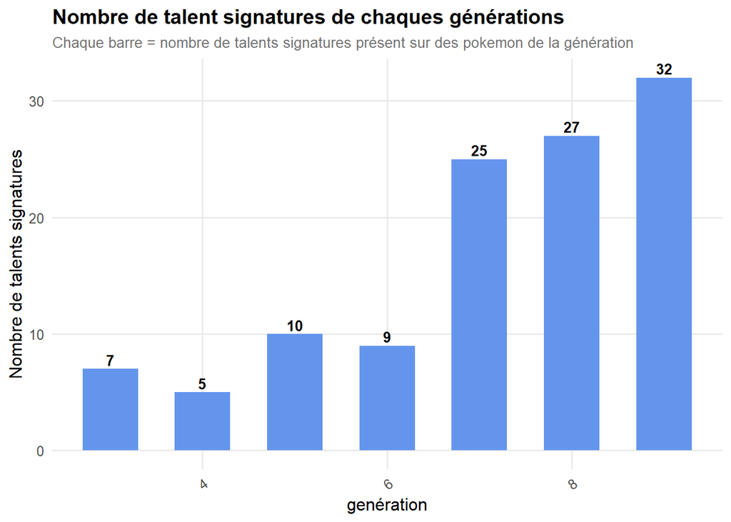

Sur ce graphique, on voit bien que au cours des générations, il y a de plus en plus de talents signatures qui sont introduits, ce qui est conforme à notre intuition initiale. Cela peut aussi s’expliquer par le fait que avec le temps, des talents qui était donné à un seul Pokemon sont donnés à un nouveau pokemon, ou rendu plus commun. On peu citer par exemple le talent Coloforce de Azumarill, qui a depuis été donné à des méga évolution et des nouveaux pokemon comme Escavarenne. La 6eme génération est peut-être sous-estimée, car nous ne prenons pas en compte les mega-évolutions dans ce graphique. On regarde ici la génération ou les talents ont été introduits et non pas la génération du pokemon auquel elles ont été donné. Le talent signature (gaz neutralisant) de Smogogo est donc compté en 8g plutôt qu’en 1g, ce qui explique l’absence de talent avant la 3ème génération.

## Graphique n°4: nombre d’attaque signature de chaque générations.

[figure not shown]

Comme pour les talents, on peut voir que de plus en plus d’attaques signatures apparaîssent au fil des années. La neuvième génération est largement la génération ou le plus d’attaque signature apparaîssent. Notre intuition semble donc être la bonne. Comme pour les talents, ces chiffres peuvent être sous-estimés, car beaucoup d’attaque qui était signatures ne le sont plus aujourd’hui.

## Question 14 : Comment sont répartis les « bons » Pokémon dans l’espace de jeu ?

On cherche ici à confronter deux dimensions du jeu : la performance compétitive des Pokémon, mesurée par leur usage moyen en Gen 1 OU sur Smogon, et leur accessibilité dans Pokémon Rouge, Bleu ou Jaune. Un Pokémon très fort mais obtenu très tardivement, très rarement, ou dans une zone optionnelle ne joue pas le même rôle dans la progression qu’un Pokémon rencontré naturellement pendant l’aventure.

La carte ci-dessous utilise un mapping manuel des zones de Kanto sur `img/kanto.png`. La densité est calculée à partir d’un score par zone : on additionne l’usage Smogon moyen des Pokémon du top retenu accessibles dans chaque lieu, directement ou via une pré-évolution.

Ce score est ensuite diffusé autour de la zone pour obtenir une densité spatiale. La couleur affichée utilise `sqrt(score)` et un plafonnement au 95e percentile afin de rendre visibles les zones moyennes sans laisser quelques zones très fortes écraser toute l’échelle. La rareté reste affichée dans les détails, mais elle ne pondère pas la couleur : sinon les rencontres fixes à 100 % dominent artificiellement l’échelle.

### Graphique n°1 : Densité spatiale de l’usage Smogon

[interactive chart not shown]

Cette carte doit être lue comme une carte d’accessibilité compétitive. Une zone est intense si elle donne accès, directement ou via une famille évolutive, à plusieurs Pokémon très utilisés, ou à un Pokémon particulièrement dominant. La rareté et le niveau d’obtention restent nécessaires pour interpréter cette accessibilité, mais ils ne modifient pas la couleur.

### Tableau n°1 : Zones contenant le plus de Pokémon compétitifs

| Zone | Familles top Smogon | Score usage Smogon | Meilleur rang | Niveau min. | Rareté max. | Accès |
| --- | --- | --- | --- | --- | --- | --- |
| Safari Zone | 6 | 2.208 | 1 | 15 | 25 | tauros; chansey; exeggutor via exeggcute; rhydon via rhyhorn; slowbro via slowpoke; dragonite via dratini |
| Cerulean Cave | 4 | 1.411 | 2 | 23 | 25 | chansey; alakazam via kadabra; rhydon; slowbro |
| Seafoam Islands | 3 | 0.608 | 6 | 15 | 25 | starmie via staryu; cloyster via shellder; slowbro via slowbro, slowpoke |
| Route 12 | 1 | 0.570 | 3 | 30 | 100 | snorlax |
| Route 16 | 1 | 0.570 | 3 | 30 | 100 | snorlax |
| Sea Route 19 | 2 | 0.484 | 6 | 15 | 25 | starmie via staryu; cloyster via shellder |
| Sea Route 20 | 2 | 0.484 | 6 | 15 | 25 | starmie via staryu; cloyster via shellder |
| Sea Route 21 | 2 | 0.484 | 6 | 15 | 25 | starmie via staryu; cloyster via shellder |
| Cinnabar Island | 2 | 0.484 | 6 | 15 | 25 | starmie via staryu; cloyster via shellder |
| Route 24 | 1 | 0.444 | 5 | 8 | 10 | alakazam via abra |
| Route 25 | 1 | 0.444 | 5 | 10 | 10 | alakazam via abra |
| Celadon City | 2 | 0.277 | 10 | 15 | 100 | jolteon via eevee; slowbro via slowpoke |

La distribution suggère que les Pokémon les plus valorisés par le métagame ne sont pas tous placés naturellement sur le chemin principal. Plusieurs menaces fortes apparaissent dans des zones tardives ou optionnelles : la Caverne Azurée concentre des Pokémon très puissants, mais elle est post-ligue ; la Centrale donne accès à Électhor, mais reste optionnelle ; les Îles Écume et le Parc Safari ajoutent aussi des espèces fortes ou rares.

À l’inverse, quelques Pokémon compétitifs sont accessibles pendant une progression plus classique. Cela nuance l’idée d’un jeu qui réserverait strictement les meilleurs Pokémon à la fin : le jeu laisse tôt ou au milieu de l’aventure certains choix très solides, mais les options les plus dominantes restent souvent associées à des contraintes de timing, de rareté ou d’exploration.

## Question 16 : Comment évolue la difficulté des Pokémon sauvages au fil du scénario ?

Les données PokeAPI permettent de traiter proprement les Pokémon sauvages, mais pas les dresseurs : faute de CSV homogène sur les équipes adverses, on les exclut de cette analyse.

L’ordre des routes est construit manuellement à partir de notre connaissance des jeux. PokeAPI ne fournit pas un vrai ordre de scénario, et certaines zones sont revisitées à plusieurs moments. Quand la donnée le permet, on sépare donc les sous-zones (`area_identifier`), par exemple les deux parties de la route 211 à Sinnoh.

On garde uniquement les rencontres standards en marchant (`walk`) afin d’éviter de mélanger progression normale, surf, pêche et rencontres spéciales. Cela est une limite claire à notre analyse : certains jeux enchaînent plusieurs zones maritimes dans leur progression, qui s’intègrent donc à la courbe de difficulté, là où d’autres ne les traitent que plus tard par des détours optionnels.

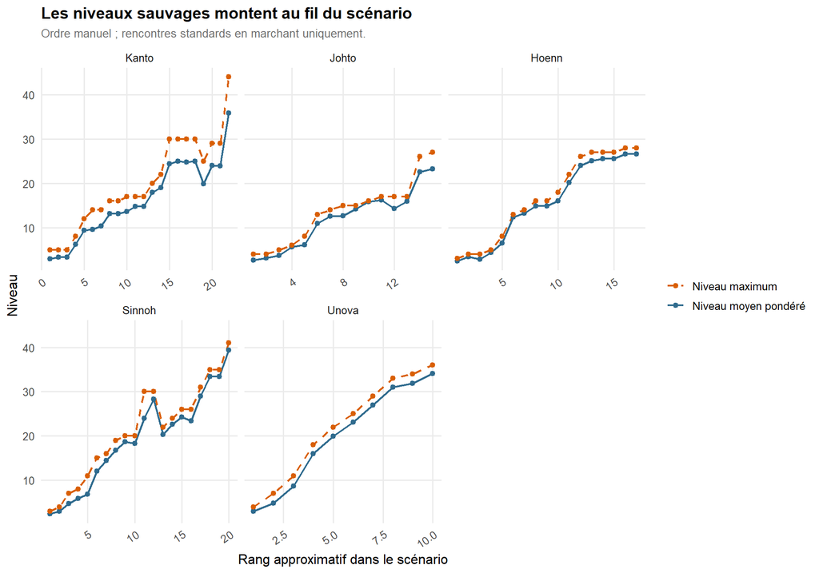

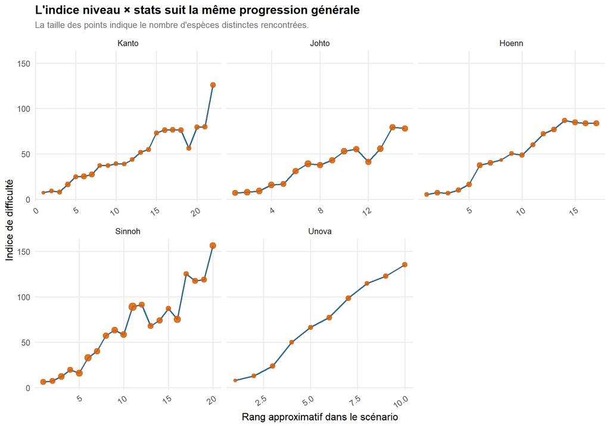

Résumé de progression sur les segments principaux du scénario

| Région | Version | Segments | Niveau départ | Niveau fin | Gain niveau | Corr. niveau | Corr. indice | Reculs > 1 niv. | Plus fort recul | Gain BST |
| --- | --- | --- | --- | --- | --- | --- | --- | --- | --- | --- |
| Kanto | FireRed / LeafGreen | 22 | 2.91 | 35.82 | 32.91 | 0.95 | 0.98 | 1 | -5.15 | 92.05 |
| Johto | HeartGold / SoulSilver | 15 | 2.68 | 23.27 | 20.60 | 0.98 | 0.97 | 1 | -1.87 | 71.23 |
| Hoenn | Emerald | 17 | 2.42 | 26.65 | 24.23 | 0.99 | 0.97 | 0 | -0.54 | 102.20 |
| Sinnoh | Platinum | 20 | 2.45 | 39.34 | 36.88 | 0.97 | 0.95 | 1 | -8.00 | 137.60 |
| Unova | Black / White | 10 | 3.00 | 34.13 | 31.13 | 1.00 | 1.00 | 0 | 0.00 | 130.90 |

Globalement, la difficulté sauvage augmente bien au fil du scénario. La hausse vient surtout des niveaux. Les statistiques de base ajoutent du bruit, mais l’indice combiné suit la même tendance.

Demeurent certaines irrégularités, notamment dûes à l’absence des routes nécessitant Surf ou la pêche, qui suivent en général le niveau des routes terrestres adjacentes, mais pas toujours (et qui ont surtout vocation à être explorées plus tard par du backtracking).

Ce qui en ressort, c’est la structure non-linéaire d’une partie du scénario : pour la région de Kanto, cela intervient à partir de Céladopole, où le joueur peut choisir de déjouer les plans de la team Rocket, partir à Lavanville et rejoindre Parmanie (au sud) par l’Est, ou bien passer par la piste cyclable et rejoindre parmanie par l’Ouest. À Johto, il y a de nouveau un plateau, après la 4ème arène à Rosalia, le joueur obtient Surf et peut partir à l’Est et pour arriver à Écorcia et au Lac Colère, ou partir à l’Ouest obtenir deux badges et revenir vers l’Est plus tard, avant d’arriver sur un pic de niveau énorme, qui compense un peu maladroitement la progression plate des zones précédentes.

Hoenn a également une structure non-linéaire avec des boucles, mais celle-ci est beaucoup plus quadrillée et tous les joueurs vont suivre globalement le même chemin. Sinnoh est plus linéaire, avec des routes en deux parties que l’on réexplore plus tard, d’où certains reculs du niveau moyen là où on ne peut pas distinguer les zones. Unys est de loin la région la plus linéaire, avec un scénario très dirigiste et peu de choix pour le joueur : elle marque le début d’une nouvelle manière de concevoir les jeux Pokémon, qui s’est éloignée petit à petit de la structure ouverte de Kanto.

## Question 17 : Le “taux de capture” est-il strictement anti-corrélé aux statistiques du Pokémon ? Certains Pokémon faibles sont-ils artificiellement insupportables à attraper ? A-t-il baissé en moyenne dans le temps ?

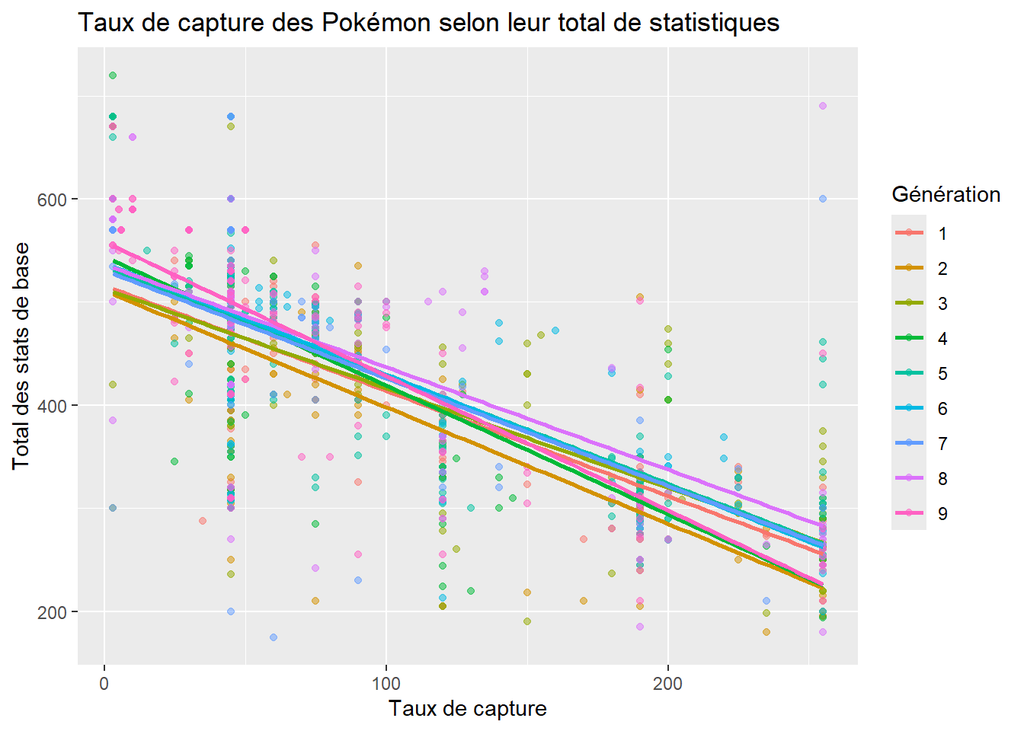

On remarque grâce aux courbes de tendances que notre hypothèse est vérifiée. Il n’y a pas de différence notable entre les générations. On remarque malgré tout quelques outliers, que l’on peut essayer d’analyser.

| pokemon_name | generation_id | capture_rate | BST |
| --- | --- | --- | --- |
| beldum | 3 | 3 | 300 |
| meltan | 7 | 3 | 300 |
| kubfu | 8 | 3 | 385 |
| mantyke | 4 | 25 | 345 |
| wyrdeer | 8 | 135 | 525 |
| basculegion-male | 8 | 135 | 530 |
| sneasler | 8 | 135 | 510 |
| overqwil | 8 | 135 | 510 |
| shuckle | 2 | 190 | 505 |
| cyclizar | 9 | 190 | 501 |

[output cut: 2 more lines]

En analysant la liste de ces outliers, on peut identifier plusieurs groupes : **Les futures menaces :**

- Wushours (Kubfu)
- Meltan
- Terhal (Beldum)

Ces pokémons ont un taux de capture très faible malgré leurs statistiques assez mauvaises. Cela s’explique très simplement : leurs évolutions sont bien plus puissantes. Wushours et Meltan évoluent respectivement en Shifours (550 BST) et Melmetal (600 BST), deux Pokémon légendaires et donc extrêmement rares. Terhal a pour évolution finale Métalosse (600 BST), qui appartient à une catégorie de Pokémons communément nommés “pseudo-légendaires”, des Pokémons communs mais très puissant. Cependant, il est le seul de cette catégorie avec un taux de capture aussi bas, ce qui le rend tristement notoire auprès des joueurs.

**Les obligatoires**

- Necrozma
- Éthernatos

Ces Pokémons sont des légendaires, mais leur taux de capture est maximal. La raison est simplement que ce sont des Pokémons que l’histoire de leur jeu force le joueur à capturer.

**Les évolutions**

- Cerbyllin (Wyrdeer)
- Paragruel (Basculegion)
- Farfurex (Sneasler)
- Qwilpik (Overqwil)

Ces Pokémons ont un taux de capture plutôt élevé par rapport à leur statistiques. La raison est un peu plus étrange que les précédentes, mais la même pour tous : il ne sont en réalité pas capturables. En effet, ces Pokémons ne sont pas disponibles à l’état sauvage, et peuvent uniquement être obtenus après évolution de leur premier stage. Ainsi, ils n’ont pas de taux de capture propre, mais héritent de celui de leur sous-évolution.

**Les inexplicables**

- Babimanta (Mantyke)
- Caratroc (Shuckle)
- Motorizard (Cyclizar)

Ces Pokémons n’ont pas vraiment de traits particuliers qui pourraient expliquer leur présence dans cette liste. ils représentent probablement des anomalies statistiques.

## Question 18 : Stéréotypes de conception des Pokémon

> Existe-t-il des stéréotypes de conception entre l’apparence des Pokémon (couleur principale, forme physique) et leur type ou leurs statistiques ? Par exemple : les Pokémon rouges sont-ils généralement de type Feu ? Les Pokémon à forme humanoïde ont-ils une attaque plus élevée ?

**Hypothèse :** Game Freak suit des “recettes” visuelles stables et utilise des archétypes pour construire son bestiaire. On s’attend à des corrélations couleur / type (rouge = Feu, bleu = Eau…) et des tendances liées à la forme (formes massives = défensives, formes bipèdes = offensives).

*Note : cette analyse est réalisée sur les Pokémon de la 1ère génération uniquement, avec correction des types passés.*

### Visualisation 1 — Couleur de conception vs Type principal

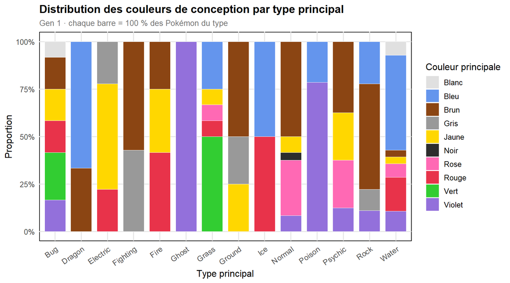

**Interprétation :** On remarque qu’effectivement, des couleurs semblent correspondre à des types. Les Pokémon de type Eau sont bleus, les types Poison sont violets, les types Électrique sont jaunes, les types Plante sont verts, etc. Les types Dragon et Spectre ne sont représentés que par une famille chacun, respectivement celles de Dracolosse et d’Ectoplasma, d’où la faible variété de couleurs. On remarque en outre que le marron est majoritaire chez plusieurs types : Combat, Sol, Normal, Roche. Cela peut s’expliquer par la présence du marron dans les éléments naturels de la vie réelle (terre, pelages, peaux). Ce graphique montre qu’effectivement, certaines couleurs sont intuitivement liées aux types, ce qui est peut-être une manière d’indiquer au joueur le type d’un monstre rencontré pour la première fois.

### Visualisation 2 — Forme physique vs Statistiques offensives/défensives

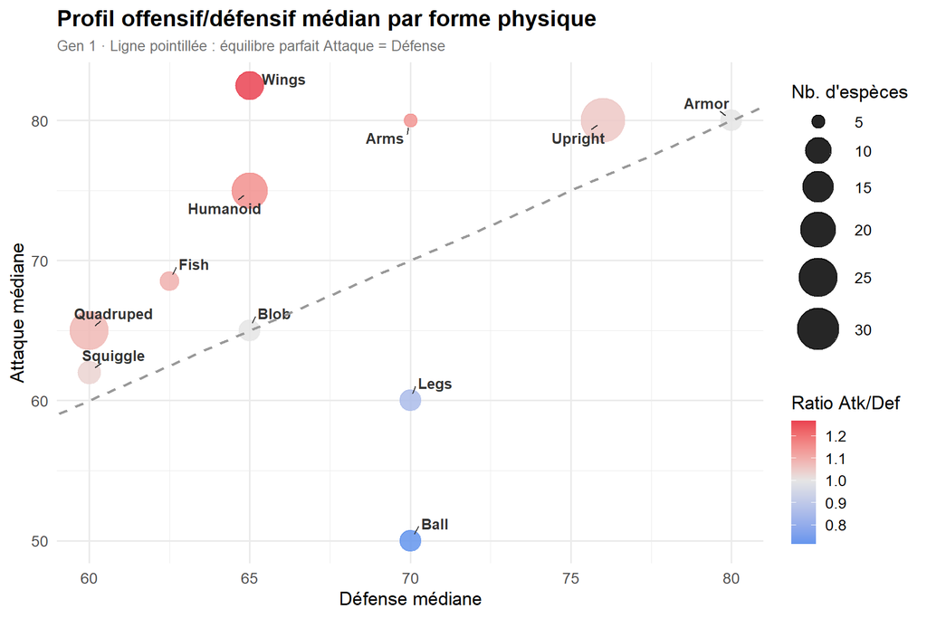

**Interprétation :** Les formes au-dessus de la diagonale ont un profil offensif (Attaque > Défense), celles en-dessous un profil défensif. Les Humanoïdes sont effectivement offensifs, conformément à l’intuition (Mackogneur, Alakazam…). Les Ailés semblent être de loin les plus offensifs, et les monstres de forme “Balle” sont d’assez loin les plus défensifs (Crustabri, Smogo, Électrode…). Ici aussi, comme pour les couleurs et les types, certaines formes sont associées à des stéréotypes liés aux statistiques.

### Visualisation 3 — Heatmap couleur × type (effectifs)

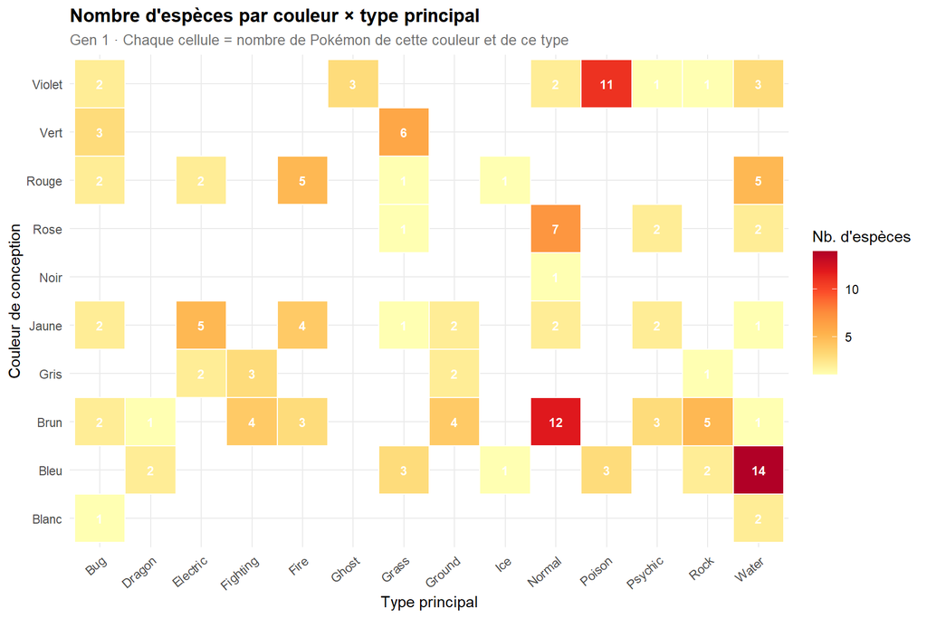

**Interprétation :** En valeurs absolues, on voit directement combien de Pokémon partagent une couleur et un type donnés. Les cellules vides (0) révèlent des associations inexistantes, tandis que les cellules foncées confirment des concentrations fortes (ex: beaucoup de Pokémon bleus de type Eau). Cette heatmap est complémentaire à la Visualisation 1, qui elle est normalisée par type.

## 19. L’habitat naturel d’un Pokémon (grotte, forêt, zone urbaine…) correspond-il à son type (e.g.: Plante = forêt), ou y a-t-il une certaine diversité par environnement ? (`pokemon_habitats.csv`, `pokemon_types.csv`, `pokemon_species.csv`)

### Graphique n°1 : Heatmap

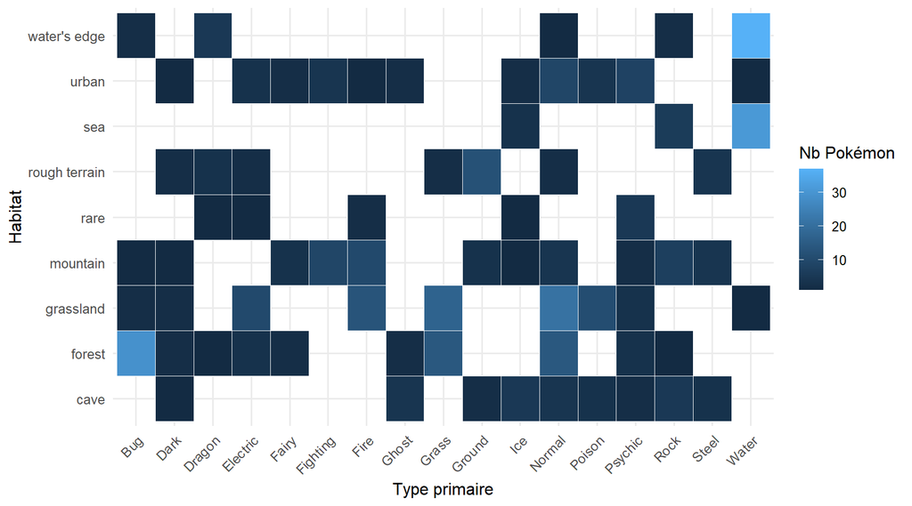

### Graphique n°2 : Stacked Bar Chart

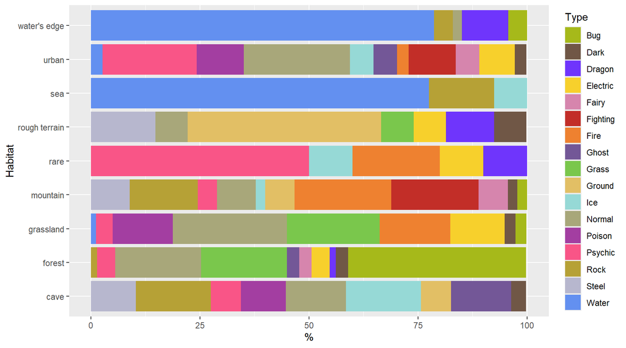

L’habitat “water’s edge” montre la corrélation la plus forte : 79% de ses espèces sont de type “Water”, ce qui confirme une correspondance directe habitat/type. À l’opposé, “mountain” accueille 11 types différents avec aucun dépassant 22%, ce qui montre que certains milieux sont au contraire très éclectiques. La réponse est donc nuancée : la corrélation existe pour dans certains millieux plus ou moins marqué (océan, forêt), mais disparaît pour des environnements moins marqué (plaine, urbain)